# HW 3: STFT, Features, and Regression (15 points)

For each markdown cell, add a cell (or cells) of code below. Reminders:

- This is an individual assignment.
- If you use GenAI tools to assist you with your homework, remember to fill out the GenAI Usage Statement at the bottom of the notebook. Even if you use GenAI, you should not be directly copying the code.
- You may only use functions/packages we have discussed in class

Read in the following files from your "audio" folder.

- /audio/country.00000.wav
- /audio/hiphop.00000.wav

Ensure that amplitudes are normalized to between -1 and 1.

```python
import numpy as np
import matplotlib.pyplot as plt
from scipy.io.wavfile import read

# Read audio files
(fs_country, country_raw) = read('../audio/country.00000.wav')
(fs_hiphop, hiphop_raw)   = read('../audio/hiphop.00000.wav')

# If stereo, take one channel
if country_raw.ndim > 1:
    country_raw = country_raw[:, 0]
if hiphop_raw.ndim > 1:
    hiphop_raw = hiphop_raw[:, 0]

# Normalize amplitudes to between -1 and 1
country_data = country_raw / np.max(np.abs(country_raw))
hiphop_data  = hiphop_raw  / np.max(np.abs(hiphop_raw))
```

## Part 1: STFT parameters and visualization (6 points)

#### Write your own STFT (3 points)

Write your own STFT function that will output a 2D matrix with shape (num_frames, num_bins), where each row contains the DFT of a single frame.

- Use a hop size equal to half the frame size (i.e., hop_size = frame_size // 2) so that frames overlap by 50%, and you should apply a hanning window to each frame (you may use `np.hanning()` for this.)
- The user should be able to vary the size of the frame (leave hop_size fixed at 50%).

*Note: You should use the built in numpy FFT function (instead of your DFT). This means you will have to work in powers of 2!*

```python
import math

def my_stft(audio_input, frame_size, sampling_rate = 44100):

    # Define frame_length (should be power of two based on input frame_size)
    frame_length = 2 ** math.ceil(np.log2(frame_size))

    # Define hop size is half the frame size
    hop_length = frame_length // 2

    # Define number of frames (m) we can extract with 50% overlap based on the total length of our signal
    # If the signal does not fit an integer number of frames, truncate
    n_mbins = (len(audio_input) - frame_length) // hop_length + 1

    # Define total number of frequency bins
    n_kbins = frame_length

    # Pre-allocate matrix for STFT. Remember it should be structured as [time_frames, frequency_bins]
    stft_matrix = np.zeros((n_mbins, n_kbins))

    # Define window
    window = np.hanning(frame_length)

    # Iterate through signal by frame
    for m in range(n_mbins):
        # index into the frame, apply window, apply fft over the frame, store in matrix
        start = m * hop_length
        frame = audio_input[start : start + frame_length] * window
        stft_matrix[m, :] = np.fft.fft(frame)

    return stft_matrix
```

#### Apply your STFT function

Apply your STFT function to the audio files listed above (country and hiphop)

```python
# your code here
fSize = 1024
country_stft = my_stft(country_data, fSize)
hiphop_stft = my_stft(hiphop_data, fSize)
```

#### Write your own spectrogram function (3 points)

Write your own spectrogram function (using `plt.pcolormesh()`) called `plot_spectrogram()` that takes the complex-valued STFT output from your above function, and the sampling rate, and plots a magnitude spectrogram in decibels.

The axes should be properly labeled (time on x-axis, Frequency on y-axis).

*Note: audio processing workflows and dataframe logic in general in Python commonly use rows = time. However, several plotting functions like pcolormesh() annoyingly expect rows = frequency and columns = time. Therefore, we simply add a step to 'transpose' our 2d array or matrix in our code below.*

```python
# your code here
def plot_spectrogram(stft_matrix, frame_size, sampling_rate):

    frame_length = 2 ** math.ceil(np.log2(frame_size))
    # Take magnitude and convert to decibels
    magnitude = np.abs(stft_matrix).T  # Transpose so rows = frequencies
    magnitude_db = 20 * np.log10(magnitude + 1e-6)  # avoid log(0)

    # Time and frequency axes
    num_frames =  stft_matrix.shape[0]  # total number of frames
    hop_size =    frame_length // 2# recall it was 50% of the frame size
    duration =    num_frames * hop_size / sampling_rate # find duration

    # Make a time axis by taking the total duration and dividing the timeline according to the number of frames:
    time_axis = np.linspace(0, duration, num_frames)
    # Ditto for frequency axis according to the number of bins
    freq_axis = np.linspace(0, sampling_rate/2, frame_length // 2)

    # Plot only up to Nyquist frequency by indexing your magnitude vector
    magnitude_db = magnitude_db[:frame_length // 2, :]

    plt.figure(figsize=(12, 5))
    plt.pcolormesh(time_axis, freq_axis, magnitude_db)
    plt.colorbar(label='Magnitude')
    plt.xlabel('Time')
    plt.ylabel('Frequency')
    plt.tight_layout()
    plt.show()
```

Plot the spectrogram of the country and hiphop audio files

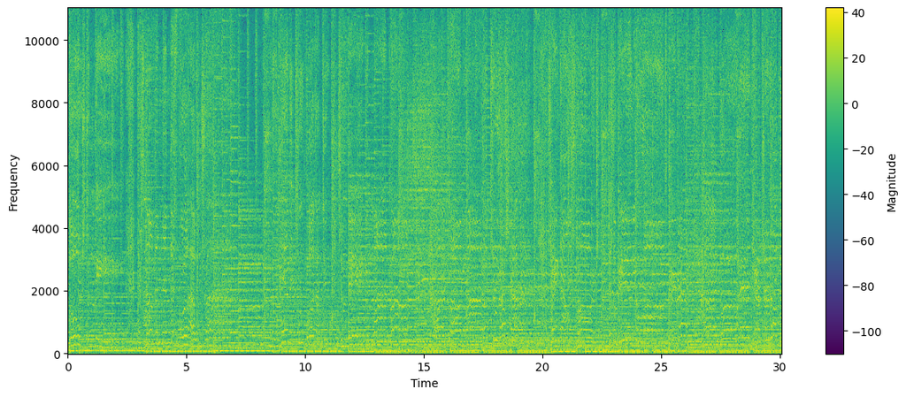

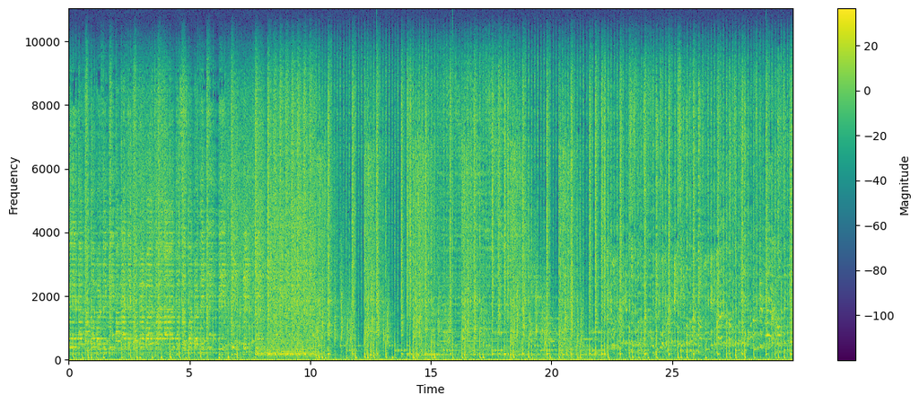

```python
plot_spectrogram(country_stft, fSize, fs_country)
plot_spectrogram(hiphop_stft,  fSize, fs_hiphop)
```

## Part 2: Feature Extraction (4 points)

We will perform feature extraction and compare the two audio files above.

Extract the following features for each file (you may use librosa functions):

- RMSE
- Spectral Centroid
- Spectral Flux
- ZCR

For each feature:

- graph the results of each feature
- briefly describe what the feature might tell us perceptually
- briefly describe whether or not this might be a useful feature for classification (based on the graphs)

1 point for each correct feature calculation and associated explanation/reasoning

```python
import librosa.feature as feature
from librosa import stft
from librosa import frames_to_time
```

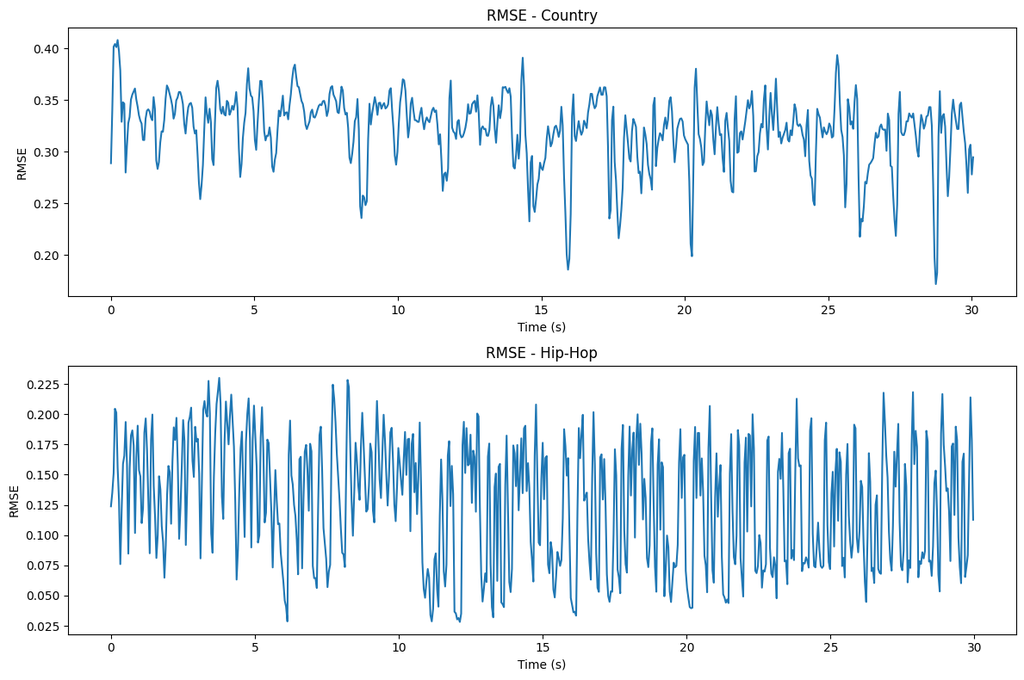

```python
def computeRMSE(audio_data, frame_length=2048, hop_length=1024):
    rmse = np.array([])
    for i in range(0, len(audio_data), hop_length):
        rms_i = np.sqrt(np.mean(audio_data[i:i+frame_length]**2))
        rmse = np.append(rmse, rms_i)
    return rmse
# RMSE for hiphop
rmseHH = computeRMSE(hiphop_data)
# RMSE for country
rmseC = computeRMSE(country_data)
# plotting

fig, ax = plt.subplots(2, 1, figsize=(12, 8))
ax[0].plot(frames_to_time(np.arange(len(rmseC)), hop_length=1024), rmseC)
ax[0].set_title('RMSE - Country')
ax[0].set_xlabel('Time (s)')
ax[0].set_ylabel('RMSE')

ax[1].plot(frames_to_time(np.arange(len(rmseHH)), hop_length=1024), rmseHH)
ax[1].set_title('RMSE - Hip-Hop')
ax[1].set_xlabel('Time (s)')
ax[1].set_ylabel('RMSE')
plt.tight_layout()
plt.show()
```

Your RMSE explantion here!

Root Mean Square Energy (RMSE) measures the average intensity of a signal on a frame-by-frame basis. Perceptually, it tracks the dynamics of the audio - louder hits are peaks, softer sounds are valleys. RMSE can offer insight if one audio file has significantly louder than the other, but otherwise it is not that effective at classifying.

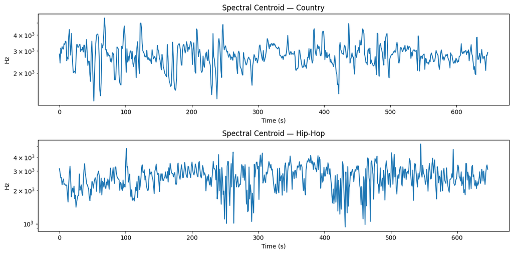

```python
# Spectral Centroid for hiphop
centroidHH = feature.spectral_centroid(y=hiphop_data.astype(float), sr=fs_hiphop, n_fft=2048, hop_length=1024)
# Spectral Centroid for country
centroidC = feature.spectral_centroid(y=country_data.astype(float), sr=fs_country, n_fft=2048, hop_length=1024)
# plotting
frames_c = range(1, centroidC.shape[1] + 1)
t_country = frames_to_time(frames_c, sr=fs_country, hop_length=1024)

frames_h = range(1, centroidHH.shape[1] + 1)
t_hiphop  = frames_to_time(frames_h, sr=fs_hiphop, hop_length=1024)

fig, axes = plt.subplots(2, 1, figsize=(12, 6))
axes[0].semilogy(centroidC[0])
axes[0].set_title('Spectral Centroid — Country')
axes[0].set_xlabel('Time (s)')
axes[0].set_ylabel('Hz')

axes[1].semilogy(centroidHH[0])
axes[1].set_title('Spectral Centroid — Hip-Hop')
axes[1].set_xlabel('Time (s)')
axes[1].set_ylabel('Hz')

plt.tight_layout()
plt.show()
```

Your centroid explanation here!

Spectral centroid is the weighted average of the frequency spectrum. Perceptually it indicates the brighness/nasality of a sound where high centroid indicaes high frequency energy, while low is more bass heavy. This is very useful for classification, as it makes it easy to differentiate instruments based on frequency contents.

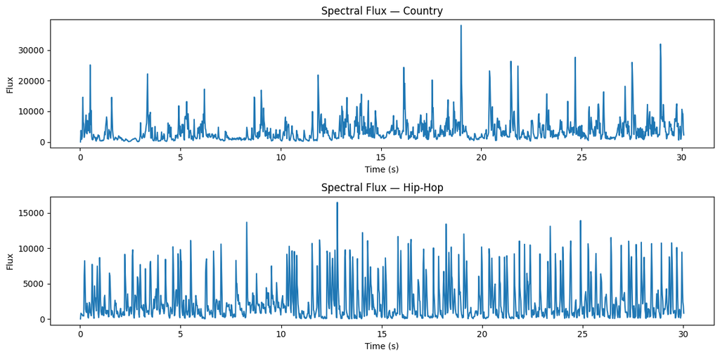

```python
# spectral flux for hiphop
stftHiphop = stft(hiphop_data, n_fft=1024, hop_length=512)
magHiphop = np.abs(stftHiphop)
diffHiphop = np.diff(magHiphop, axis=1)
fluxHiphop = np.sum(diffHiphop**2, axis=0)
fluxHiphop = np.concatenate(([0], fluxHiphop))
framesHiphop = range(1, len(fluxHiphop) + 1)
t_hiphop = frames_to_time(framesHiphop, sr=fs_hiphop, hop_length=512)

# spectral flux for country
stftCountry = stft(country_data, n_fft=1024, hop_length=512)
magCountry = np.abs(stftCountry)
diffCountry = np.diff(magCountry, axis=1)
fluxCountry = np.sum(diffCountry**2, axis=0)
fluxCountry = np.concatenate(([0], fluxCountry))
framesCountry = range(1, len(fluxCountry) + 1)
t_country = frames_to_time(framesCountry, sr=fs_country, hop_length=512)

# plotting
fig, axes = plt.subplots(2, 1, figsize=(12, 6))
axes[0].plot(t_country, fluxCountry)
axes[0].set_title('Spectral Flux — Country')
axes[0].set_xlabel('Time (s)')
axes[0].set_ylabel('Flux')

axes[1].plot(t_hiphop, fluxHiphop)
axes[1].set_title('Spectral Flux — Hip-Hop')
axes[1].set_xlabel('Time (s)')
axes[1].set_ylabel('Flux')

plt.tight_layout()
plt.show()
```

Your spectral flux explanation here!

Spectral flux measures how quickly the power spectrum of a signal is changing on a frame by frame basis. In other words, it tracks the velocity of attacks, meaning spikes correspond to drum hits or chord strum, while flatter sections indicate sustains, or slow attacks.

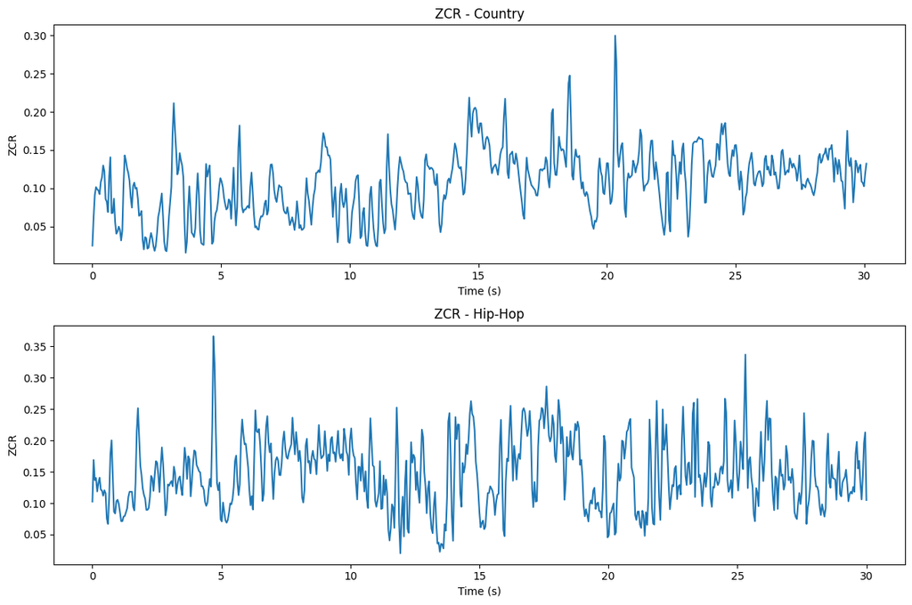

```python
# ZCR for hiphop
zcrHiphop = feature.zero_crossing_rate(y=hiphop_data.astype(float), frame_length=2048, hop_length=1024)
# ZCR for country
zcrCountry = feature.zero_crossing_rate(y=country_data.astype(float), frame_length=2048, hop_length=1024)
# plotting
axC = np.linspace(0, len(country_data) / fs_country, len(zcrCountry[0]))
axH = np.linspace(0, len(hiphop_data) / fs_hiphop, len(zcrHiphop[0]))

fig, ax = plt.subplots(2, 1, figsize=(12, 8))
ax[0].plot(axC, zcrCountry[0])
ax[0].set_title('ZCR - Country')
ax[0].set_xlabel('Time (s)')
ax[0].set_ylabel('ZCR')

ax[1].plot(axH, zcrHiphop[0])
ax[1].set_title('ZCR - Hip-Hop')
ax[1].set_xlabel('Time (s)')
ax[1].set_ylabel('ZCR')
plt.tight_layout()
plt.show()
```

Your ZCR explanation here!

ZCR counts how often the waveform crosses 0 per frame. Perceptually, a high ZCR shows more noise/higher-frequencies (because faster oscillations), while lower is more harmonic with lower frequencies. This is usefull for classificatoin as genres can differ in noise concentrations - hip hop has more percussive hard hits compared to country.

## Part 3: Binomial Logistic Regression (5 points)

Like in activity 7, you will build a binomial classifier with logistic regression. You will use the GTZAN genre dataset 'features_30_sec.csv' this time to classify hiphop vs country music.

### Explore the data and select your features (3 points)

Use graphing and correlation techniques to determine 5 features you will use for your classification.

You must at a minimum create 1 bar graph and 1 box plot in addition to computing the correlation between the features you select.

Construct your Pandas dataframe for your chosen features. Remember you may want to do some scaling and normalization.

```python
import pandas as pd
from sklearn import preprocessing

df = pd.read_csv('../Datasets/features_30_sec.csv')
columns = ['filename', 'length', 'rms_mean', 'spectral_centroid_mean', 'spectral_bandwidth_mean', 'rolloff_mean', 'zero_crossing_rate_mean', 'label']
df = df[columns]


genres = ['country', 'hiphop']
df = df[df['label'].isin(genres)].copy()
df
```

|  | filename | length | rms_mean | spectral_centroid_mean | spectral_bandwidth_mean | rolloff_mean | zero_crossing_rate_mean | label |
| --- | --- | --- | --- | --- | --- | --- | --- | --- |
| 200 | country.00000.wav | 663300 | 0.248418 | 2797.844810 | 2847.551887 | 6221.176656 | 0.107205 | country |
| 201 | country.00001.wav | 661760 | 0.230516 | 2938.155358 | 2839.657689 | 6279.551665 | 0.126988 | country |
| 202 | country.00002.wav | 669680 | 0.146586 | 2308.673365 | 2618.607096 | 5190.053453 | 0.074162 | country |
| 203 | country.00003.wav | 661408 | 0.204364 | 2174.033869 | 2280.888606 | 4347.882042 | 0.102564 | country |
| 204 | country.00004.wav | 661408 | 0.209498 | 2966.086095 | 2848.106749 | 6349.153274 | 0.124161 | country |
| ... | ... | ... | ... | ... | ... | ... | ... | ... |
| 495 | hiphop.00095.wav | 661794 | 0.103468 | 2735.775141 | 2295.702995 | 5419.955522 | 0.157556 | hiphop |
| 496 | hiphop.00096.wav | 661794 | 0.110829 | 1752.626789 | 1812.043498 | 3490.710421 | 0.083117 | hiphop |
| 497 | hiphop.00097.wav | 661794 | 0.118497 | 2582.203954 | 2526.331057 | 5731.928836 | 0.116005 | hiphop |
| 498 | hiphop.00098.wav | 661794 | 0.119111 | 2538.747388 | 2341.475858 | 5353.807121 | 0.100706 | hiphop |
| 499 | hiphop.00099.wav | 661504 | 0.153691 | 1962.680819 | 1916.813711 | 3797.754246 | 0.101515 | hiphop |

200 rows × 8 columns

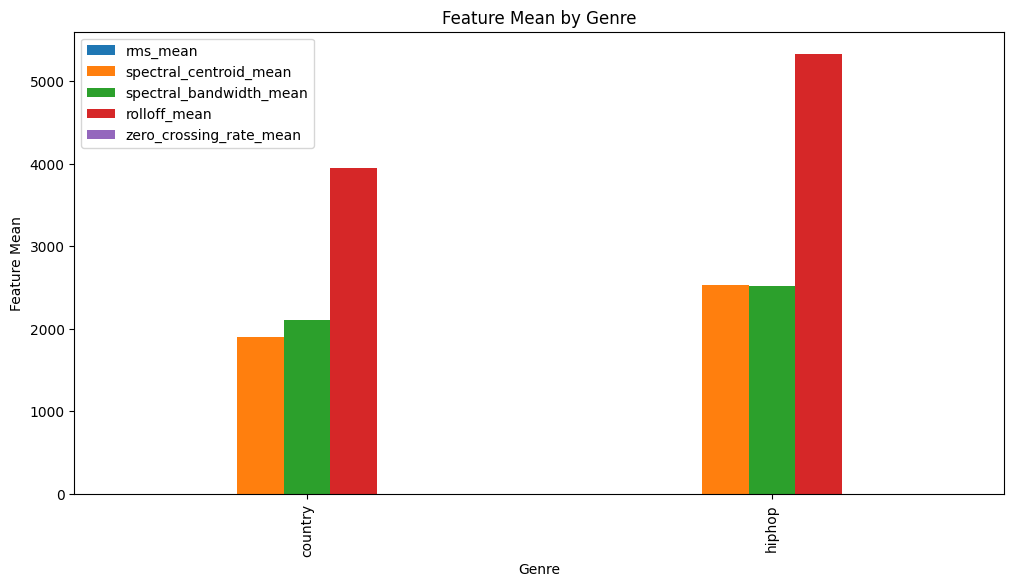

```python
features = ['rms_mean', 'spectral_centroid_mean', 'spectral_bandwidth_mean', 'rolloff_mean', 'zero_crossing_rate_mean']
grouped = df.groupby('label').mean(numeric_only=True)

groupedFeatures = grouped[features]
groupedFeatures.plot.bar(figsize=(12, 6), title='Feature Mean by Genre')
plt.xlabel('Genre')
plt.ylabel('Feature Mean')
plt.show()
```

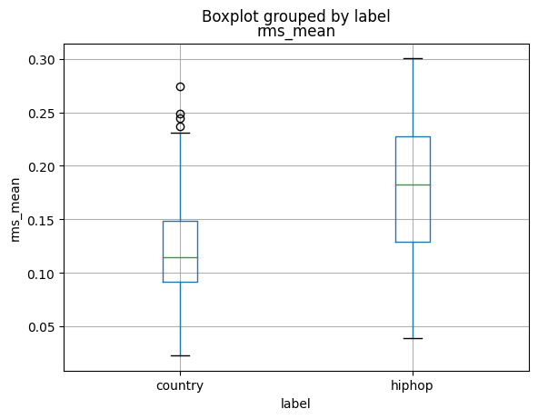

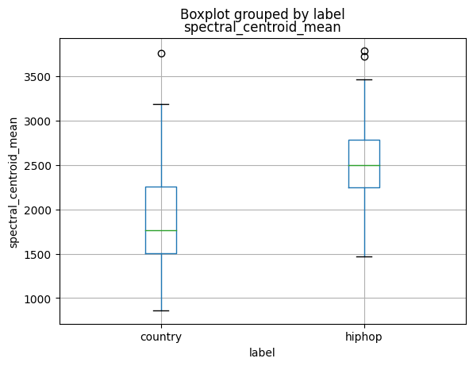

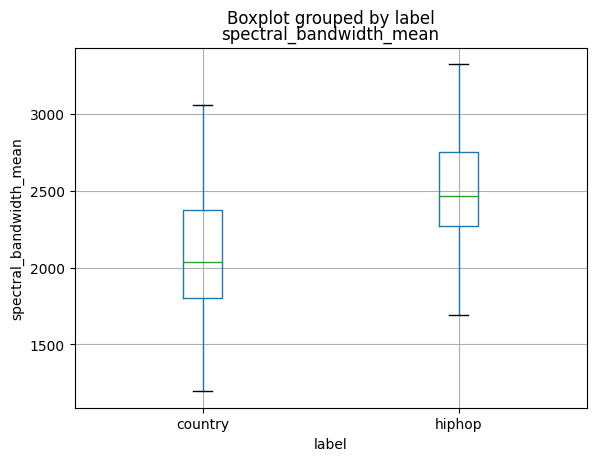

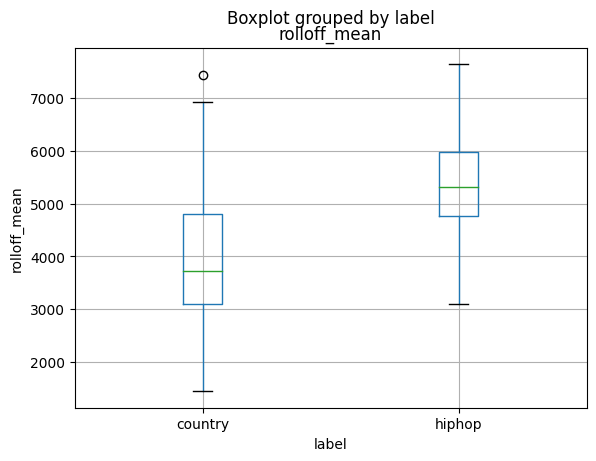

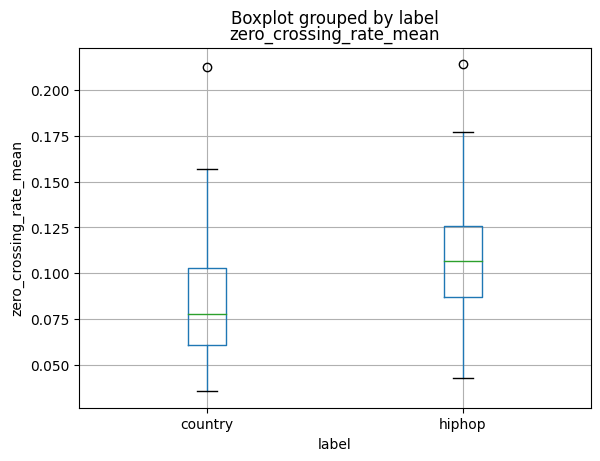

```python
for feat in features:
    plt.figure()
    df.boxplot(column=feat, by='label')
    plt.ylabel(feat)
    plt.title(feat)
    plt.show()
```

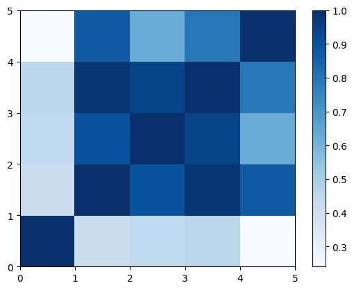

```python
numDf = df[features]

plt.pcolor(numDf.corr(), cmap='Blues')
plt.colorbar()
plt.show()
```

```python
labelDummy = pd.get_dummies(df['label'], drop_first=True)
labelDummy.columns = ['hiphop']

dfModel = pd.concat([labelDummy, df[features]], axis=1)

scaler = preprocessing.StandardScaler()
dfModel[features] = scaler.fit_transform(dfModel[features])
dfModel.head()
```

|  | hiphop | rms_mean | spectral_centroid_mean | spectral_bandwidth_mean | rolloff_mean | zero_crossing_rate_mean |
| --- | --- | --- | --- | --- | --- | --- |
| 200 | 0 | 1.591235 | 0.957335 | 1.207889 | 1.175173 | 0.345604 |
| 201 | 0 | 1.295284 | 1.185979 | 1.190265 | 1.218603 | 0.939295 |
| 202 | 0 | -0.092235 | 0.160200 | 0.696779 | 0.408038 | -0.645985 |
| 203 | 0 | 0.862928 | -0.059203 | -0.057163 | -0.218521 | 0.206346 |
| 204 | 0 | 0.947803 | 1.231494 | 1.209127 | 1.270386 | 0.854450 |

### Train/Test Split

Use sklearn to split your data into testing and training sets. Remember you will need to define your categories, predictors, and test size. Use 30% test size.

```python
from sklearn.model_selection import train_test_split

categories = dfModel.iloc[:, 0]
predictors = dfModel.iloc[:, 1:]

pred_train, pred_test, cat_train, cat_test = train_test_split(predictors, categories, test_size=0.3, random_state=25)
```

### Train the Model and Evaluate (2 points)

Train the model using logistic regression.

Calculate the confusion matrix (and view as a data frame). Calculate the accuracy, precision, recall, and F1 scores.

Explain what the confusion matrix and accuracy tell us about your model.

```python
from sklearn.linear_model import LogisticRegression
from sklearn.metrics import classification_report, confusion_matrix

model = LogisticRegression(solver='lbfgs')
model.fit(pred_train, cat_train)
predictions = model.predict(pred_test)

cm = confusion_matrix(cat_test, predictions)
cm_df = pd.DataFrame(cm, columns=['Predicted Country', 'Predicted Hip-Hop'], index=['Actual Country', 'Actual Hip-Hop'])
print(cm_df)
TN, FP, FN, TP = cm.ravel()
accuracy = (TP + TN) / (TN + FP + FN + TP)

accuracy
```

```
                Predicted Country  Predicted Hip-Hop
Actual Country                 22                  7
Actual Hip-Hop                  4                 27
```

```
0.8166666666666667
```

Your model interpretation here!

The confusion matrix show the 4 possible outcomes for each test sample - true negatives are country clips correctly predicted as country, false negatives are hip-hop clips predicted as country, false positives are country clips incorrectly predicted as hip-hop, and true positives which are hip-hop correctly predicted as such.

The accuracy, (TP+TN)/Total, is the proportion of all samples classified correctly. Anything well above 50% shows proof of learning,and our model's accuracy was 81.7%, which means it is a working differentiator of country and hip-hop genres.

GenAI Usage Statement:

- Tool used and date of access
- The input (prompt) you provided
- A copy of the output
- A description of how you used or edited the AI-generated content
- used AI to find out what .ravel() is and used it in finding the accuracy of the model
- used vscode inbuilt intellisense autofill for plotting - auto titles, etc